# Análisis del desempeño futbolístico en 5 ligas europeas entre 2014 y 2020

# 1.Importancia

La industria del deporte y, en específico, la del fútbol, es una de las más importantes a nivel mundial, por lo que toda la información concerniente o relacionada a este ámbito resulta sumamente valiosa, tanto para los propios equipos como para agentes externos al deporte (casas de apuestas) , y de alto interés por parte de la población. El valor de estas radica en el conocimiento de factores, características y patrones que dan lugar al determinado desempeño de un equipo, jugador o incluso de una liga entera. Por este motivo, en este estudio analizaremos el desempeño futbolístico en 5 ligas europeas entre 2014 y 2020, tomando en cuenta información como goles, asistencias, disparos, victorias de local, victorias de visitante

## 1.1.Objetivos

### 1.1.1.Objetivo principal:

- Analizar el desempeño individual y colectivo en cinco ligas europeas de fútbol(española, inglesa, italiana, alemana y francesa) entre los años 2014 y 2020.

### 1.1.2.Objetivos específicos:

- Clasificar los equipos de las 5 ligas en base al nivel ofensivo.
- Determinar la liga más ofensiva durante el periodo de tiempo analizado.
- Determinar la temporada de mayor productividad goleadora.
- Describir numéricamente la cantidad goles que se hacen cada minuto en cada liga, cada año.
- Clasificar a los jugadores de todas las ligas según su media goleadora.
- Clasificar las ligas en base a la cantidad de infracciones y tarjetas recibidas por partido.
- Determinar los equipos con más victorias de locales y visitantes.
- Evaluar la evolución en cuanto a la cantidad de goles realizados en cada liga a lo largo de los años.
- Comparar la frecuencia de disparos de uno de los jugadores más determinantes de las cinco ligas a lo largo de los años.
- Determinar los cuatro equipos más representativos de cada liga en cuanto a la cantidad de goles.
- Establecer relaciones entre variables y detectar patrones significativos.
- Formular y validar hipótesis sobre variables representativas en nuestro estudio.
- Aplicar regresión lineal para formular predicciones en base a los patrones encontrados.

# 2.Descripción del estudio

Para este proyecto se utilizará una base de datos pública y fiable (obtenida en https://www.kaggle.com/technika148/football-database, una web dedicada al rubro de la ciencia de datos) la cual registra información sobre cinco ligas europeas de fútbol entre los años 2014 y 2020. Esta base de datos se encuentra en formato csv y es de descarga libre.

Según la propia fuente de esta base de datos, la información provista corresponde a:

- **Premier League**: 20 equipos, 380 partidos.
- **La Liga**: 20 equipos, 380/380 partidos.
- **Serie A**: 20 equipos, 380/380 partidos.
- **Bundesliga**: 18 equipos, 306/306 partidos.
- **Ligue 1**: 20 equipos, 378/380 partidos (dos partidos suspendidos).

# 3.Factibilidad

Durante el curso se llevaran a cabo diferentes actividades, entregables y presentaciones. Contamos con diferentes herramientas, tales como, sesiones de clase, asesorias, libros y materia adicional, para el desarrollo de estas. Además, desarrollamos la siguiente tabla con información sobre el cronográma de asignaciones del proyecto para cumplir con los objetivos de este.

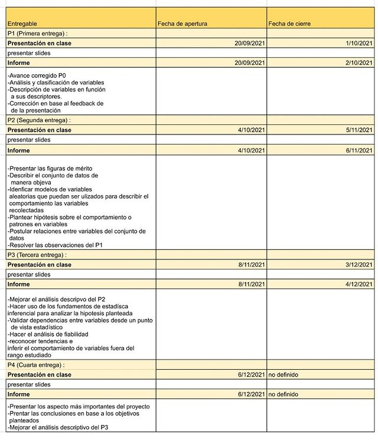

# 4.Clasificación de variables

## 4.1.Variables categóricas

### 4.1.1.Variables nominales

| Variable | Definicion |
| --- | --- |
| player | nombre del jugador |
| playerID | código del jugador |
| gameID | código del juego |
| playerID | código del jugador |
| position | posición del jugador |
| substituteIn | código del jugador entrante al hacer un cambio |
| substituteOut | código del jugador saliente al hacer un cambio |
| leagueID | código de la liga |
| teamID | código del equipo |
| team | nombre del equipo |
| league | nombre de la liga |
| understatNotation | sigla del nombre de la liga |
| shooterID | código del jugador que realiza el disparo |
| assisterID | código del jugador que realiza la asistencia |
| situation | situación en la que se da el disparo (corner o juego libre) |
| lastAction | acción anterior al disparo |
| shotType | parte del cuerpo con la que el jugador realiza el disparo |
| shotResult | resultado del disparo |

### 4.1.2.Variables ordinales

| Variable | Definicion |
| --- | --- |
| season | temporada en la que se jugó el partido |

## 4.2.Variables numéricas

### 4.2.1.Variables Continuas

| Variable | Definicion |
| --- | --- |
| xGoals | indica la probabilidad de convertir un disparo en gol |
| xGoalsChain | indica la probabilidad de convertir un disparo en gol segun la posición del jugador |
| xGoalsBuildup | indica la probabilidad de convertir un disparo o pase clave en gol |
| xAssists | indica la probabilidad de un pase en conventirse en gol |
| xGoal | indica la probabilidad de convertir en gol un disparo de un jugador |
| date | fecha en la que se realizó el partido |
| ppda | número de pases enemigos completados a través de la línea de defensa |

### 4.2.2.Variables Discretas

| Variable | Definicion |
| --- | --- |
| player goals | número de goles del jugador en el juego |
| player ownGoals | número de autogoles del jugador en el juego |
| player shots | número de disparos del jugador en el juego |
| player assists | número de asistencias del jugador en el juego |
| keyPasses | número de pases clave del jugador en el juego (no necesariamente terminan en gol) |
| player yellowCard | número de tarjetas amarillas del jugador en el juego |
| player redCard | número de tarjetas rojas del jugador en el juego |
| time | tiempo jugado por el jugador en el partido |
| minute | minuto en el que el jugador realiza el disparo |
| team goals | número de goles del equipo en el encuentro |
| team shots | número de disparos del equipo en el encuentro |
| shotsOnTarget | número de disparos al arco del equipo en el encuentro |
| deep | indica que tan lejos juega de la línea de meta juega un jugador |
| fouls | número de faltas cometidas por el equipo en el encuentro |
| corners | número de saques de esquina del equipo en el encuentro |
| yellowCards | número de tarjetas amarillas del equipo en el encuentro |
| redCards | número de tarjetas rojas del equipo en el encuentro |

# 5.Limpieza de datos

Nuestra base de datos cuenta con información como apariciones individuales por jugador, disparos realizados en cada partido, estadísticas de cada equipo por partido e información de los partidos disputados dentro del periodo de tiempo mencionado.

Lo primero que realizaremos será cargar cada archivo **`csv`** a través de la librería **`readr`**.

```r
library(readr)
library(tidyverse)
appearances <- read_csv("Data/appearances.csv")
games <- read_csv("Data/games.csv")
leagues <- read_csv("Data/leagues.csv")
shots <- read_csv("Data/shots.csv")
teams <- read_csv("Data/teams.csv")
teamstats <- read_csv("Data/teamstats.csv")
players <-read.csv("Data/players.csv")
```

Utilizando la función **`nrow()`** podremos contar la cantidad de observaciones (filas) correspondientes a los 4 data frames de nuestra base de datos y utilizando la función **`ncol()`** podremos contar la cantidad de variables (columnas).

```r
n_observaciones <- nrow(appearances) + nrow(games) + nrow (shots) + nrow(teamstats)
n_variables <- ncol(appearances) + ncol(games) + ncol(shots) + ncol(teamstats)
```

Es así que calculamos la existencia de **719096 observaciones y 80 variables.**

Dado que nuestra base de datos esta estructurada de un modo relacional, en donde nombres correspondientes a jugadores y ligas están dados en base a ID’s en los principales *data frames*, debemos utilizar algunas funciones para adaptar cada uno de ellos a lo que nuestro estudio requiere:

- *Data frame* con los datos correspondientes a las apariciones de cada jugador en todos los partidos.

```r
apariciones_jugadores <- players %>% right_join(appearances,by="playerID") %>% left_join(leagues,by="leagueID") %>% left_join(games %>% select(gameID,season),by="gameID")

apariciones_jugadores %>% rename(ID = playerID, player = name.x, league = name.y, league_notation = understatNotation) ->
n_apariciones
remove(apariciones_jugadores)
apariciones_jugadores <- distinct(n_apariciones)
rm(n_apariciones)
```

- *Data frame* con los datos correspondientes a los partidos jugados por cada equipo.

```r
estadisticas_equipos <- teams %>% right_join(teamstats,by= "teamID") %>% right_join (apariciones_jugadores %>% select(league,gameID),by="gameID") %>% rename(team=name) %>% distinct
```

- *Data frame* con los datos correspondientes a los disparos realizados por cada jugador en cada partido.

```r
shots <- shots %>% rename(playerID = shooterID)
disparos <- players %>% inner_join(shots,by="playerID") %>% inner_join(games %>% select(gameID,season),by="gameID") %>% inner_join (apariciones_jugadores %>% select(league,gameID),by="gameID") %>% distinct
disparos <- disparos %>% rename(player=name)
```

También seleccionamos las columnas correspondientes a las variables que consideraremos de cada *data frame* y descartamos las que no necesitaremos.

Habiendo realizado la limpieza de datos, tenemos **706416 observaciones y 24 variables.**

# 6.Descripción de los datos

## 6.1.Descriptores numéricos y análisis

### Goles y disparos por equipo

| team | total_goals | total_shots | total_shots_OT |
| --- | --- | --- | --- |
| Barcelona | 698 | 4097 | 1800 |
| Paris Saint Germain | 642 | 3836 | 1588 |
| Bayern Munich | 628 | 4261 | 1708 |
| Real Madrid | 628 | 4463 | 1746 |
| Manchester City | 620 | 4609 | 1664 |
| Napoli | 542 | 4645 | 1692 |
| Juventus | 533 | 4220 | 1502 |
| Liverpool | 519 | 4267 | 1534 |
| Borussia Dortmund | 505 | 3503 | 1355 |
| Roma | 499 | 4239 | 1469 |

[output cut: 136 more lines]

### Goles, disparos y faltas por liga

| league | total_goals | total_shots_OT | total_fouls | total_red_cards |
| --- | --- | --- | --- | --- |
| Serie A | 7476 | 23665 | 74232 | 687 |
| Premier League | 7213 | 22743 | 57506 | 348 |
| La Liga | 7072 | 22077 | 73053 | 611 |
| Ligue 1 | 6656 | 21139 | 67042 | 649 |
| Bundesliga | 6324 | 19867 | 56720 | 322 |

La liga con más goles y más disparos resulta ser la Serie A (liga italiana), además de ser la que más disparos tiene. Podemos notar que la liga con menos goles y disparos , la Bundesliga, también es la liga con menos faltas, mientras que la Serie A, la más goleadora, es la que más faltas presenta. En base a esta información podríamos interpretar la diferencia de intensividad de juego en cada campeonato.

### Minuto de gol en cada liga

| season | league | avg_minute_goal | med_minute | mode_minute | min_minute | max_min | sd_minute |
| --- | --- | --- | --- | --- | --- | --- | --- |
| 2014 | Bundesliga | 49.56423 | 50 | 77 | 0 | 95 | 26.25135 |
| 2014 | La Liga | 49.75706 | 51 | 72 | 0 | 94 | 26.23405 |
| 2014 | Ligue 1 | 49.90508 | 51 | 59 | 0 | 94 | 26.52754 |
| 2014 | Premier League | 47.78782 | 47 | 47 | 0 | 96 | 26.58860 |
| 2014 | Serie A | 48.19261 | 49 | 18 | 0 | 94 | 26.12427 |
| 2015 | Bundesliga | 49.86635 | 52 | 52 | 0 | 95 | 25.69313 |
| 2015 | La Liga | 48.21307 | 49 | 49 | 0 | 95 | 26.82846 |
| 2015 | Ligue 1 | 50.04069 | 52 | 55 | 0 | 95 | 26.31869 |
| 2015 | Premier League | 49.86103 | 50 | 47 | 0 | 97 | 26.06468 |
| 2015 | Serie A | 49.48494 | 50 | 92 | 0 | 96 | 26.92533 |

[output cut: 25 more lines]

En la última tabla tenemos descriptores numéricos en cuanto a la cantidad de goles que se han realizado por minuto en cada liga y cada año. Se evidencia una cierta tendencia en cuanto al minuto promedio de gol , el cual se aproxima al minuto central de la duración que suelen tener los partidos. Podemos inferir que esto sucede porque , al tener una gran cantidad de datos con cierto grado de aletoriedad existe una tendencia común y lógica en cada caso. Asimismo, la desviación estándar, considerando que contamos con promedios similares en cada fila, es en todos los casos muy aproximada, por lo que esto evidencia más aún en cómo la aletoriedad y la cantidad de datos influye en cuanto a la representatividad de una muestra.

### Goles por jugador

| player | goal_avg | goals_median | goals_sd | max_goals |
| --- | --- | --- | --- | --- |
| Cristiano Ronaldo | 0.959821429 | 1.0 | 1.01698224 | 5 |
| Lionel Messi | 0.950617284 | 1.0 | 0.94782789 | 4 |
| Erling Haaland | 0.930232558 | 1.0 | 1.05549241 | 4 |
| Robert Lewandowski | 0.926940639 | 1.0 | 0.93069731 | 5 |
| Zlatan Ibrahimovic | 0.792000000 | 1.0 | 0.90068075 | 4 |
| Kylian Mbappe-Lottin | 0.722972973 | 1.0 | 0.83152958 | 4 |
| Harry Kane | 0.705627706 | 0.0 | 0.84950800 | 4 |
| Sergio Agüero | 0.702127660 | 0.0 | 0.94024445 | 5 |
| Luis Suárez | 0.692000000 | 0.5 | 0.84379141 | 4 |
| Neymar | 0.682634731 | 1.0 | 0.79220464 | 4 |

[output cut: 6368 more lines]

### Asistencias por jugador

| player | assists_avg | assists_median | assists_cv | max_assists | total_assists |
| --- | --- | --- | --- | --- | --- |
| Kevin De Bruyne | 0.455399061 | 0 | 1.499257 | 3 | 97 |
| Jadon Sancho | 0.432692308 | 0 | 1.395034 | 2 | 45 |
| Brian Oddei | 0.400000000 | 0 | 1.369306 | 1 | 2 |
| Lionel Messi | 0.399176955 | 0 | 1.644474 | 3 | 97 |
| Thomas Müller | 0.399082569 | 0 | 1.542958 | 3 | 87 |
| Ángel Di María | 0.378787879 | 0 | 1.580321 | 3 | 75 |
| Neymar | 0.365269461 | 0 | 1.655745 | 2 | 61 |
| Christian Brüls | 0.333333333 | 0 | 1.500000 | 1 | 3 |
| Dimitri Payet | 0.324074074 | 0 | 1.674515 | 2 | 70 |
| James Rodríguez | 0.304635762 | 0 | 1.856668 | 3 | 46 |

[output cut: 2563 more lines]

Para jugadores que han dado mas de una asistencia a lo largo de las 7 temporadas los de mejor promedio de asistencias son Kevin De Bruyne, Jadon Sancho, Brian Oddei y Lionel Messi. Este último también forma parte del podio de jugadores con mayor promedio goleador, por lo que se denota la influencia que tiene al momento de generar goles en cada partido. Tanto Messi como De Bruyne han logrado alcanzar un máximo de 3 asistencias en un mismo partido y cuentan con 97 asistencias en total.

### Victorias de local

| team | league | t_wins_h_avg |
| --- | --- | --- |
| Juventus | Serie A | 15.8571429 |
| Barcelona | La Liga | 15.0000000 |
| Paris Saint Germain | Ligue 1 | 14.5714286 |
| Manchester City | Premier League | 14.1428571 |
| Real Madrid | La Liga | 14.1428571 |
| Atletico Madrid | La Liga | 13.8571429 |
| Bayern Munich | Bundesliga | 13.5714286 |
| Napoli | Serie A | 12.7142857 |
| Sevilla | La Liga | 12.5714286 |
| Liverpool | Premier League | 12.4285714 |

[output cut: 136 more lines]

Los 4 equipos con más promedio de victorias por temporada son Juventus, Barcelona, Paris Saint Germain y Manchester City. Coincidentemente, estos 4 equipos han sido campeones de sus ligas locales en repetidas ocasiones entre el 2014 y el 2020.

### Victorias de visitante

| team | league | t_wins_a_avg |
| --- | --- | --- |
| Barcelona | La Liga | 12.1428571 |
| Paris Saint Germain | Ligue 1 | 12.1428571 |
| Bayern Munich | Bundesliga | 12.0000000 |
| Manchester City | Premier League | 12.0000000 |
| Real Madrid | La Liga | 11.7142857 |
| Juventus | Serie A | 11.4285714 |
| Napoli | Serie A | 10.5714286 |
| Liverpool | Premier League | 10.2857143 |
| Chelsea | Premier League | 9.8571429 |
| Atletico Madrid | La Liga | 9.4285714 |

[output cut: 134 more lines]

De manera similar a la anterior tabla, en este caso tenemos cantidad de victorias promedio por temporada, pero de visitante y ya no de local. Se evidencia el descenso de la Juventus, que es el equipo con mayor promedio de victorias de local, a la sexta posición, por lo que podríamos inferir la existencia de un mal desempeño y resultados principalmente fuera de casa.Por otro lado, Barcelona , Paris Saint Germain y Manchester City se mantienen en el top 4, al cual se les une el Bayern Munich.

### Disparos por jugador

| player | shots_avg | shots_median | shots_sd | max_shots | total_shots |
| --- | --- | --- | --- | --- | --- |
| Cristiano Ronaldo | 5.991071429 | 6.0 | 2.56396391 | 14 | 1342 |
| Lionel Messi | 5.119341564 | 5.0 | 2.38412371 | 12 | 1244 |
| Robert Lewandowski | 4.305936073 | 4.0 | 2.47232599 | 13 | 943 |
| Zlatan Ibrahimovic | 4.056000000 | 4.0 | 2.66489726 | 14 | 507 |
| Harry Kane | 3.835497835 | 4.0 | 2.34404789 | 11 | 886 |
| Lorenzo Insigne | 3.831168831 | 4.0 | 2.28455645 | 13 | 885 |
| Sergio Agüero | 3.797872340 | 4.0 | 2.27320964 | 11 | 714 |
| Neymar | 3.652694611 | 3.0 | 2.15073018 | 11 | 610 |
| Carlos Tévez | 3.562500000 | 3.0 | 1.96645251 | 7 | 114 |
| Edin Dzeko | 3.524886878 | 3.0 | 2.39802298 | 11 | 779 |

[output cut: 6374 more lines]

La tabla presenta descriptores numéricos sobre los disparos que realizó cada jugador a lo largo de las 7 temporadas en estudio, tales como la media de disparos por partido, la mediana, la desviación estándar, el máximo de disparos en un partido y el total de disparos. Cristiano Ronaldo y Lionel Messi, quienes lideran la tabla de goles promedio por partido, se encuentran en los dos primeros lugares en cuando a media de disparos. Además, si ordenamos nuestro data frame según disparos totales, los tres primeros lugares se mantendrían igual, lo cual resulta lógico pues los jugadores que mejor promedio de disparo tienen serían también los que más veces han disparado.

### Minuto de disparo

| player | avg_minute_shot | med_minute | mode_minute | min_minute | max_minute | cv_minute | total_shots |
| --- | --- | --- | --- | --- | --- | --- | --- |
| Cristiano Ronaldo | 46.935748 | 47.0 | 46 | 0 | 95 | 0.566346169 | 1463 |
| Lionel Messi | 49.377874 | 50.0 | 50 | 0 | 96 | 0.525641237 | 1392 |
| Robert Lewandowski | 47.159138 | 48.0 | 64 | 0 | 95 | 0.551109436 | 974 |
| Lorenzo Insigne | 43.074611 | 43.0 | 34 | 0 | 97 | 0.586259111 | 965 |
| Harry Kane | 46.749156 | 47.0 | 46 | 0 | 96 | 0.550847421 | 889 |
| Luis Suárez | 47.431566 | 49.0 | 49 | 0 | 96 | 0.549112849 | 811 |
| Edin Dzeko | 49.062893 | 51.0 | 70 | 0 | 96 | 0.551523434 | 795 |
| Fabio Quagliarella | 47.112840 | 48.0 | 34 | 0 | 96 | 0.540534736 | 771 |
| Gonzalo Higuaín | 45.282723 | 46.0 | 6 | 0 | 97 | 0.602865514 | 764 |
| Sergio Agüero | 45.583113 | 46.0 | 31 | 0 | 99 | 0.565707391 | 758 |

[output cut: 5255 more lines]

### Faltas y tarjetas amarillas por equipo

| team | fouls_avg | fouls_median | fouls_cv | max_fouls | min_fouls | total_fouls |
| --- | --- | --- | --- | --- | --- | --- |
| Carpi | 16.684211 | 16.5 | 0.2414045 | 26 | 9 | 634 |
| Cesena | 16.605263 | 17.0 | 0.2636335 | 27 | 7 | 631 |
| Hamburger SV | 16.404412 | 16.0 | 0.2640397 | 29 | 5 | 2231 |
| Getafe | 16.324561 | 16.0 | 0.2878969 | 30 | 5 | 3722 |
| Ingolstadt | 15.882353 | 16.0 | 0.2735918 | 27 | 7 | 1080 |
| Darmstadt | 15.779412 | 16.0 | 0.2486833 | 25 | 7 | 1073 |
| Leganes | 15.552632 | 15.0 | 0.2705541 | 28 | 7 | 2364 |
| Spezia | 15.552632 | 15.0 | 0.2486639 | 25 | 6 | 591 |
| Torino | 15.530075 | 15.0 | 0.2963278 | 29 | 5 | 4131 |
| Frosinone | 15.500000 | 15.5 | 0.2962127 | 28 | 7 | 1178 |

[output cut: 136 more lines]

| team | ycards_avg | ycards_median | ycards_cv | max_ycards | total_ycards |
| --- | --- | --- | --- | --- | --- |
| Getafe | 3.131579 | 3.0 | 0.5277618 | 8 | 714 |
| Granada | 2.952632 | 3.0 | 0.5263993 | 7 | 561 |
| Leganes | 2.914474 | 3.0 | 0.5499265 | 8 | 443 |
| Rayo Vallecano | 2.807018 | 3.0 | 0.5380451 | 8 | 320 |
| Alaves | 2.784211 | 3.0 | 0.5160411 | 7 | 529 |
| Almeria | 2.763158 | 3.0 | 0.5350359 | 6 | 105 |
| Carpi | 2.763158 | 3.0 | 0.4159179 | 5 | 105 |
| Frosinone | 2.763158 | 3.0 | 0.4759873 | 7 | 210 |
| SPAL 2013 | 2.763158 | 3.0 | 0.4821989 | 6 | 315 |
| Sporting Gijon | 2.763158 | 3.0 | 0.5476403 | 7 | 210 |

[output cut: 136 more lines]

### Pases clave por jugador

| player | total_pases | promedio_pases | minimo_pases | maximo_pases |
| --- | --- | --- | --- | --- |
| Dimitri Payet | 716 | 3.314814815 | 0 | 9 |
| Kevin De Bruyne | 650 | 3.051643192 | 0 | 10 |
| Lionel Messi | 596 | 2.452674897 | 0 | 9 |
| Christian Eriksen | 554 | 2.270491803 | 0 | 9 |
| Alejandro Gomez | 527 | 2.321585903 | 0 | 9 |
| Hakan Calhanoglu | 504 | 2.355140187 | 0 | 11 |
| Ángel Di María | 484 | 2.444444444 | 0 | 10 |
| Mesut Özil | 481 | 3.044303797 | 0 | 12 |
| Lorenzo Insigne | 480 | 2.077922078 | 0 | 10 |
| Eden Hazard | 463 | 2.247572816 | 0 | 8 |

[output cut: 6374 more lines]

Un pase clave es una jugada que puede iniciar una situación de gol (no necesariamente termina en esto). Este pase es uno que lleva directamente a un disparo de un jugador del mismo equipo al arco contrario, este no debe confundirse con asistencia ya que un pase clave, a diferencia de las asitencias, no necesariamente van a dejar al compañerp sólo ante el portero en ocasión de gol.

Los pases clave muestran la contribución que tiene un jugador para el aspecto ofensivo en la generacion de jugadas de gol, es decir, cuánto contribuye este a que su equipo obtenga la victoria y lo vuelva más competitivo.

En la tabla se puede comparar el desempeño en cantidad de pases clave que realizó cada jugador en total, promedio, minimo y máximo en un periodo de 6 años (2014 - 2020). Como se menciono anteriormente, los pases clave indican que tanto un jugador es capaz de armar y contribuir un ataque ofensivo, por lo que a su vez nos dice que tan competitivo es.

## 6.2.Descriptores gráficos y análisis

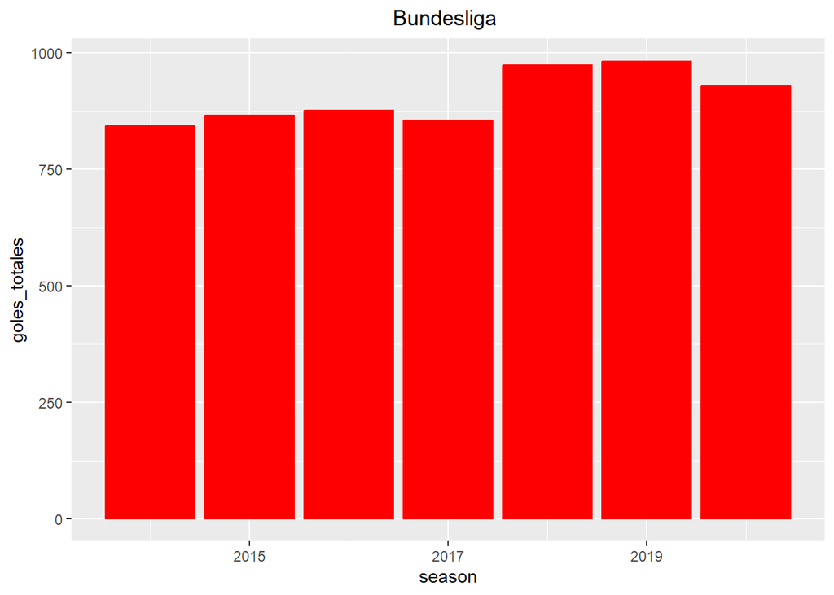

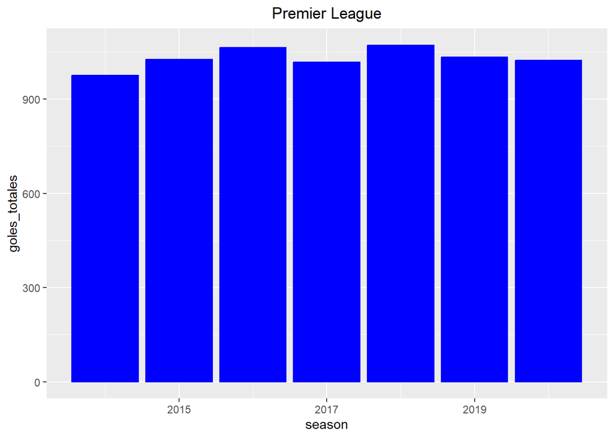

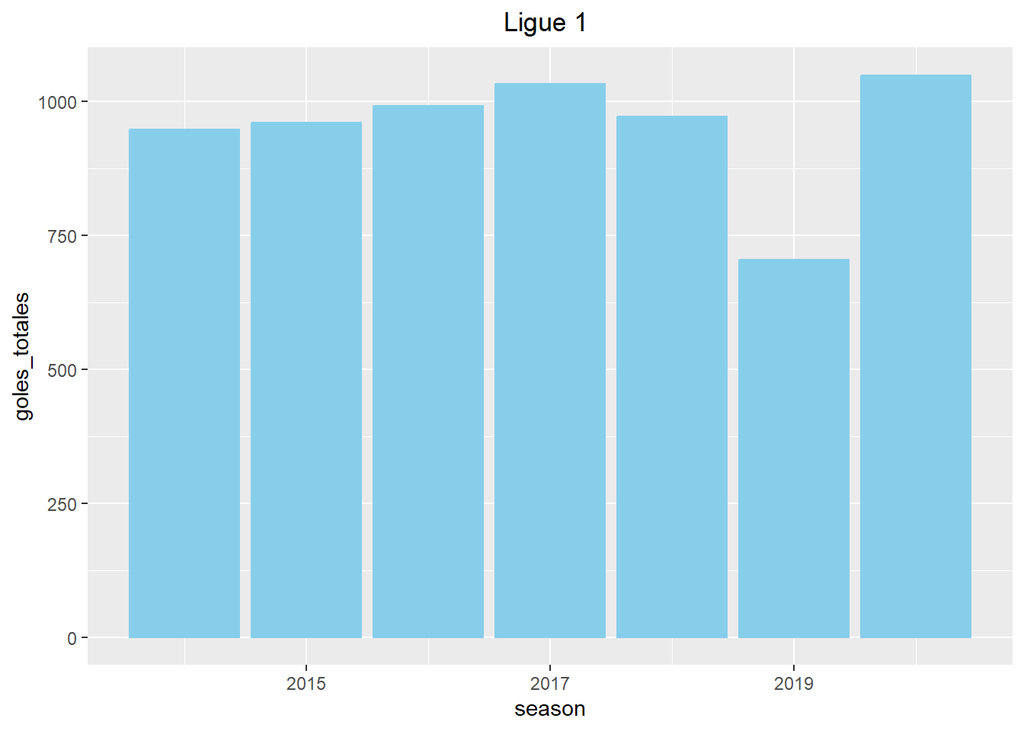

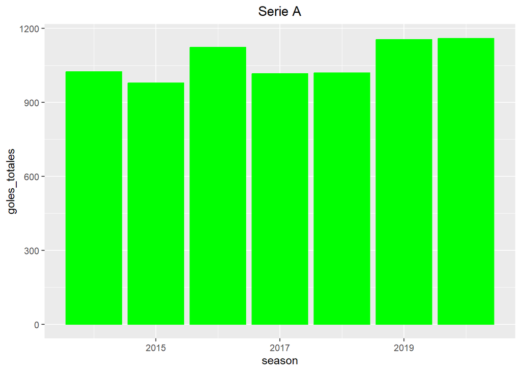

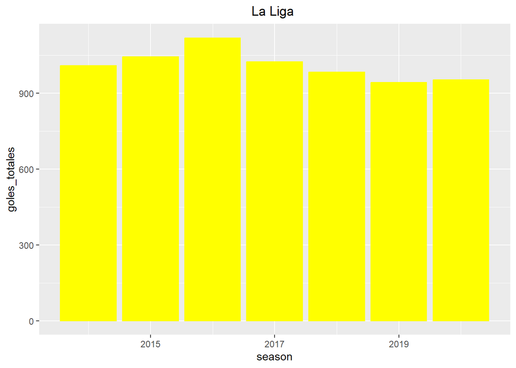

La temporada de más goles en la Bundesliga fue la del 2019, mientras que la de menor cantidad fue el 2014.

La temporada de más goles en la Premier League fue la del 2018, mientras que la de menor cantidad fue el 2014.

La temporada de más goles en la Ligue 1 fue la del 2020, mientras que la de menor cantidad, notoriamente, fue el 2019.

La temporada de más goles en la Serie A fue la del 2020, mientras que la de menor cantidad fue el 2015.

La temporada de más goles en La Liga fue la del 2016, mientras que la de menor cantidad fue 2019.

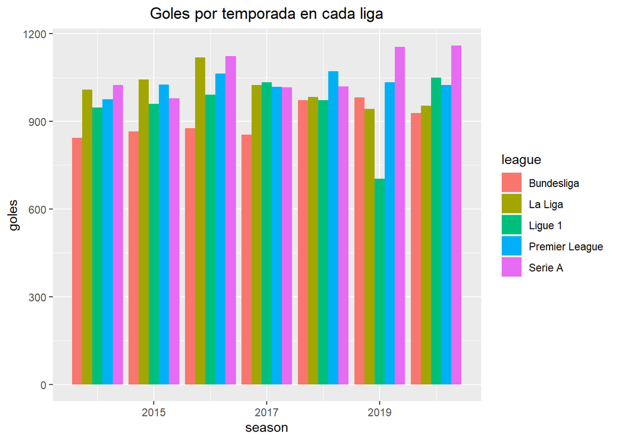

El gráfico de barras presenta una comparación de la cantidad de goles totales por liga en cada año. Por lo general, la liga con más goles por temporada es la Serie A , mientras que la liga con menos goles es la Bundesliga. A partir del gráfico también se evidencia una caída la cantidad de goles en la Liga española desde el 2016.

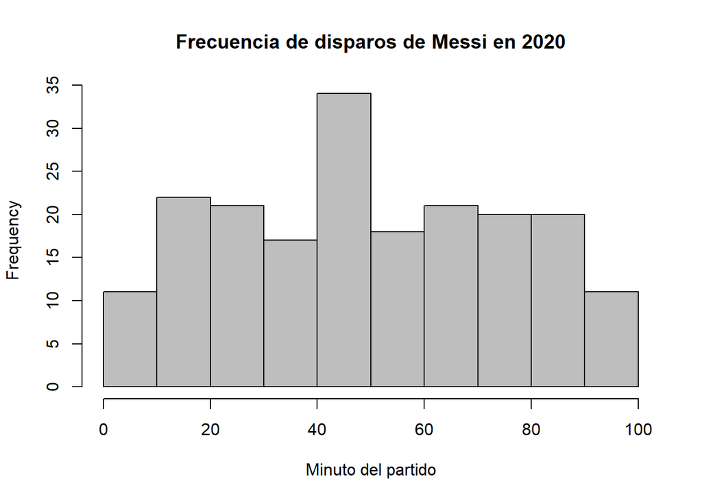

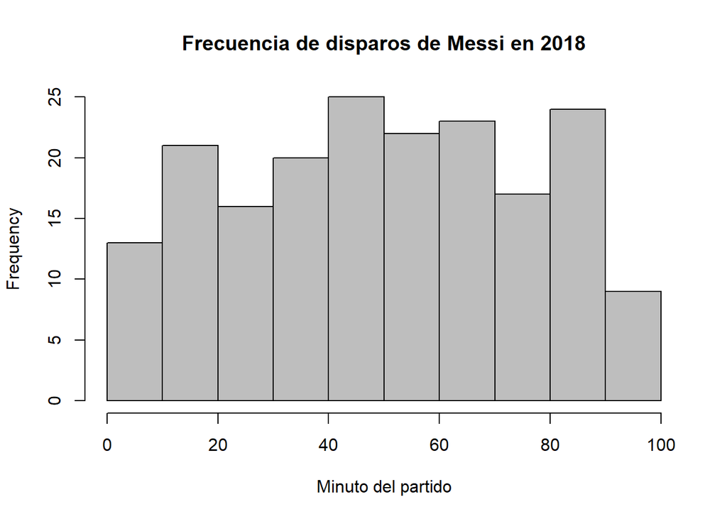

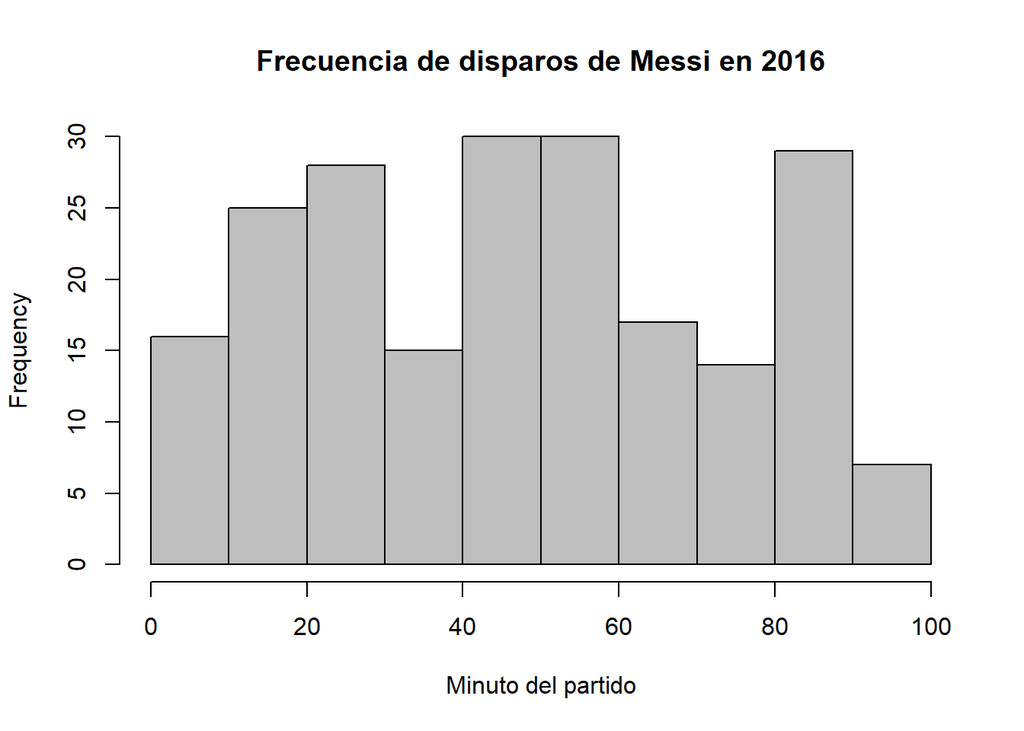

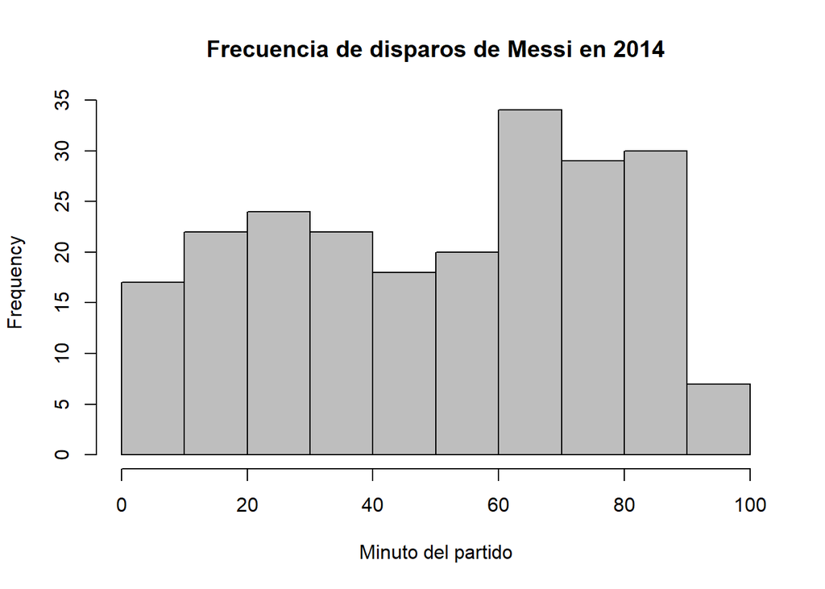

La frecuencia de disparos al arco por minuto de partido en promedio de Messi en el 2020 indican que el jugador tiene mayor frecuencia de disparos entre los minutos 40 y 50 (mitad del partido) y menor frecuencia al inicio y final del mismo.

La frecuencia de disparos al arco por minuto de partido en promedio de Messi en el 2018 indican que el jugador tiene mayor frecuencia de disparos entre los minutos 40- 50, seguido por los minutos 80-90 y menor frecuencia al inicio y final del mismo.

La frecuencia de disparos al arco por minuto de partido en promedio de Messi en el 2016 indican que el jugador tiene mayor frecuencia de disparos entre los minutos de 40 a 60 y menor frecuencia al final del mismo.

La frecuencia de disparos al arco por minuto de partido en promedio de Messi en el 2014 indican que el jugador tiene mayor frecuencia de disparos entre los minutos de 60 a 70 y menor frecuencia al final del mismo.

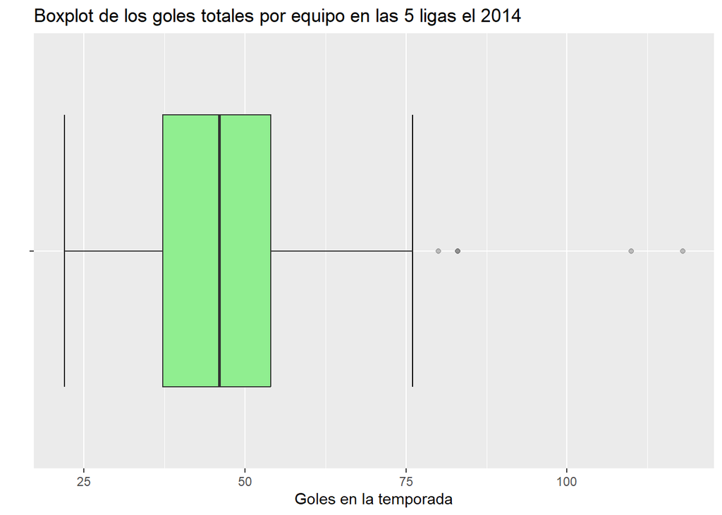

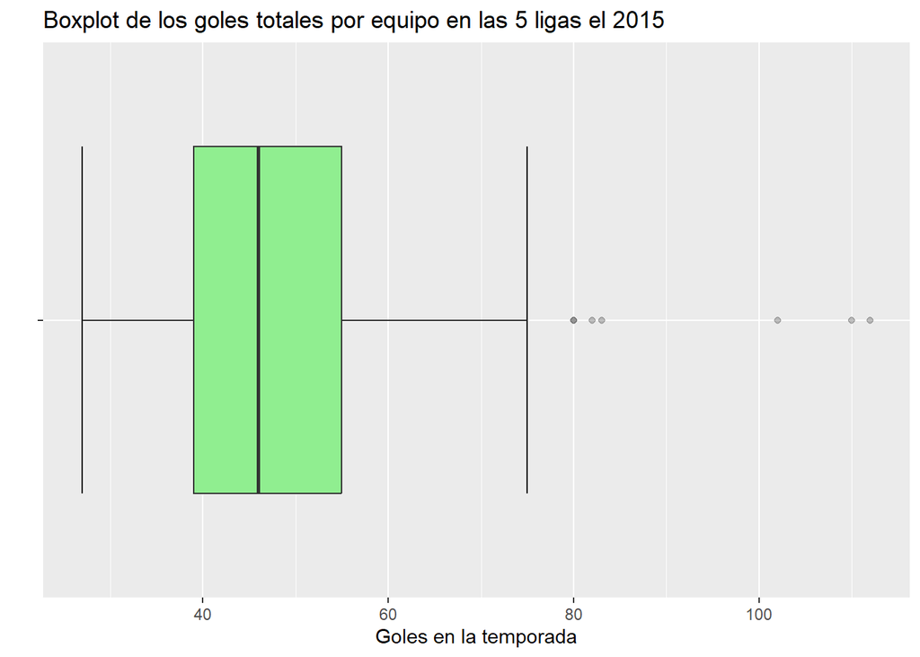

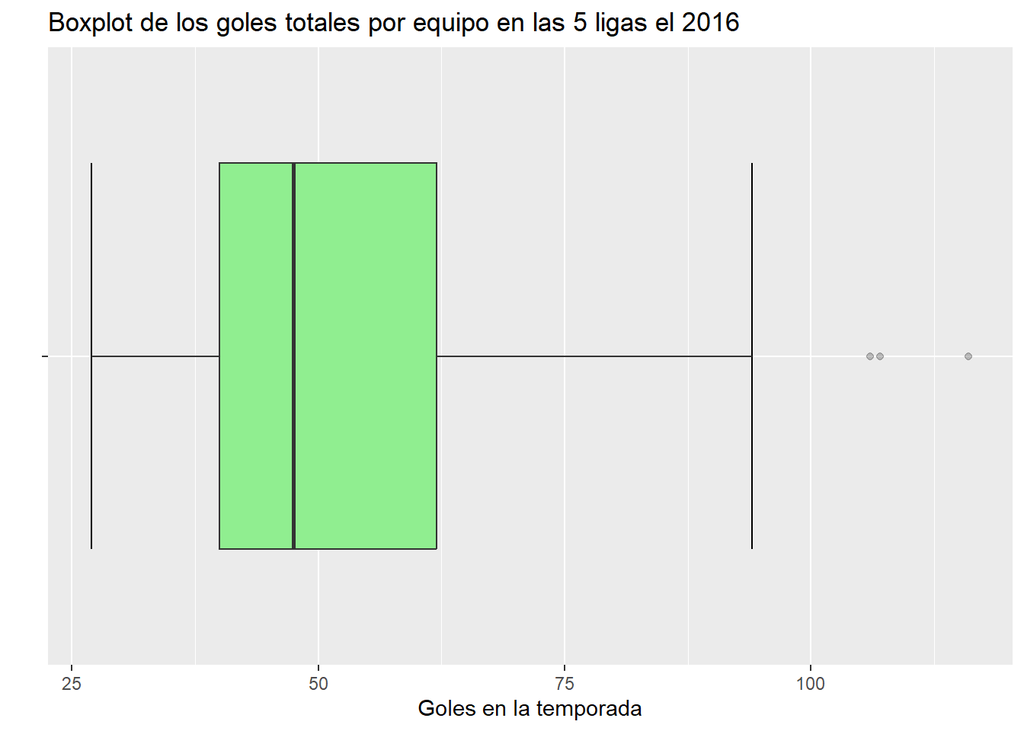

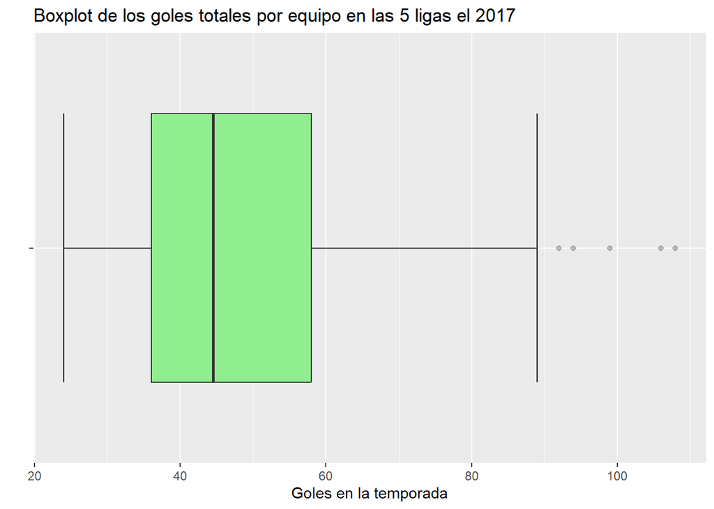

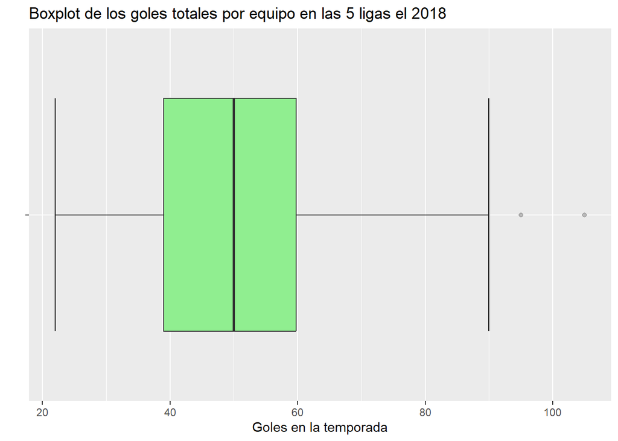

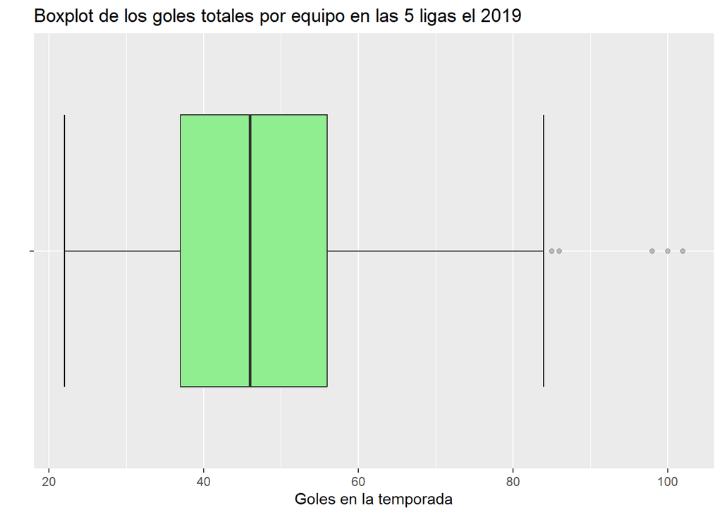

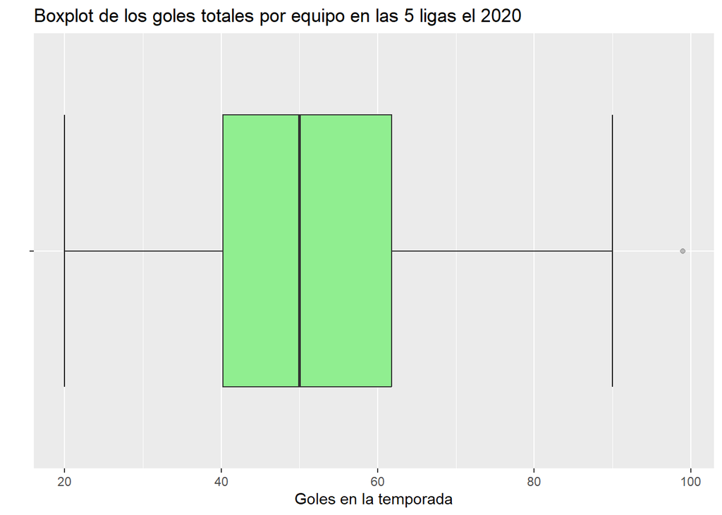

### Cantidad goles por equipo en cada liga en el periodo 2014-2020

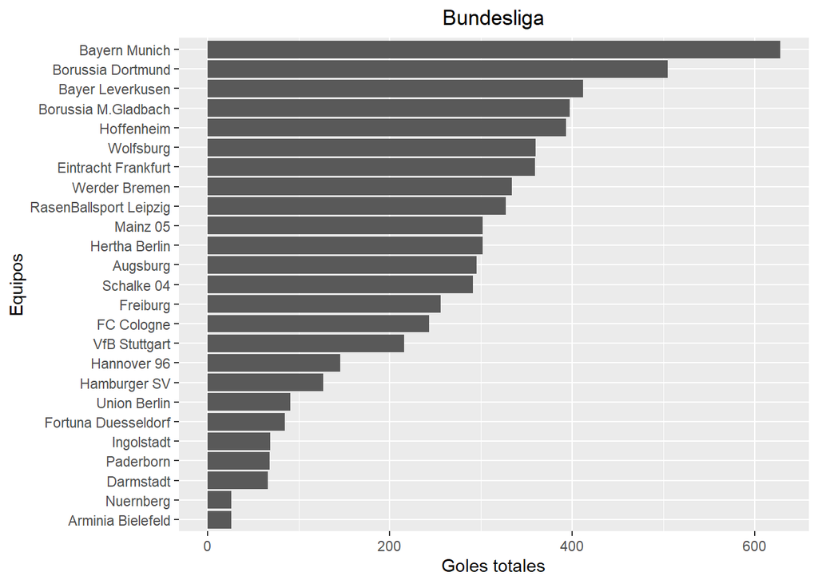

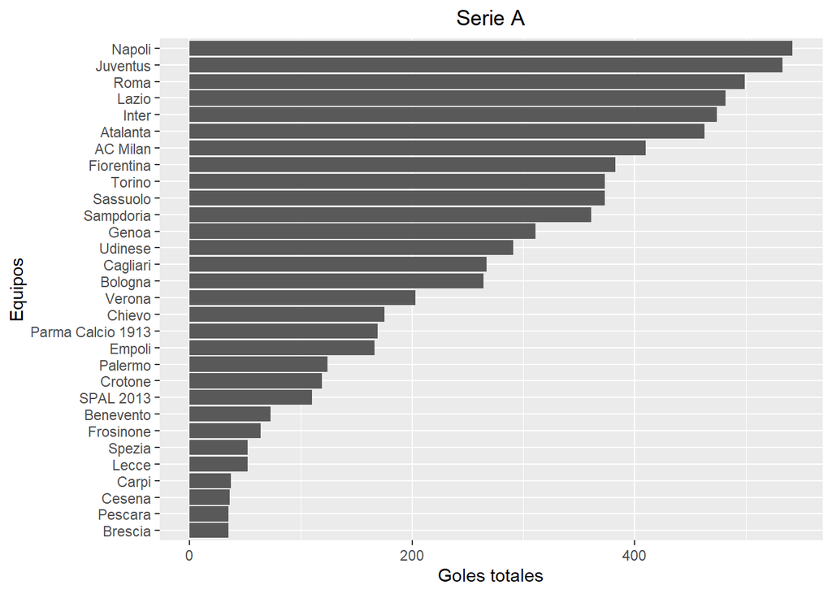

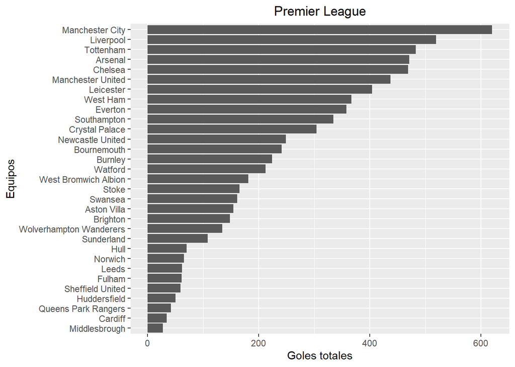

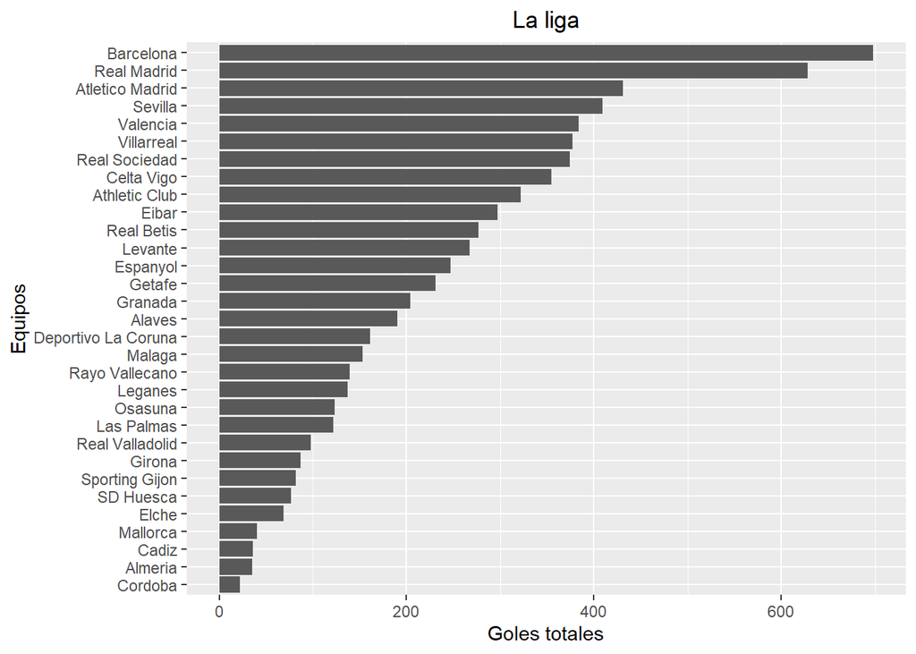

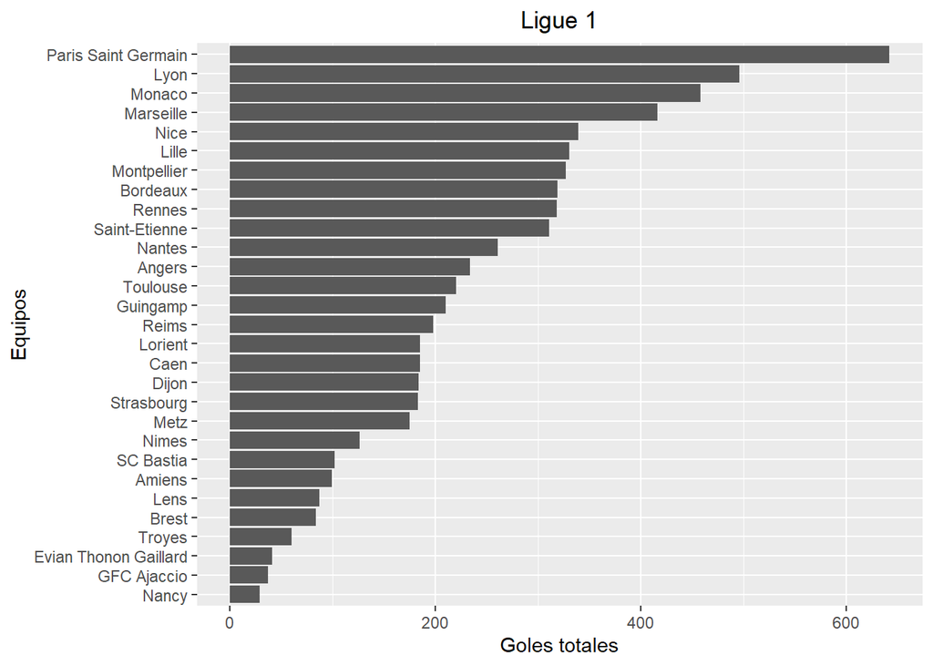

Los gráficos de barras horizontales representan la cantidad de goles totales de cada equipo en sus respectivas ligas del 2014 al 2020. Barcelona, Bayern, Manchester City, Paris Saint Germain y Napoli lideran sus respectivas ligas. Sorprendentemente, a pesar de liderar la tabla goleadora de su liga, el Napoli nunca ha sido campeón de la Serie A en este periodo.

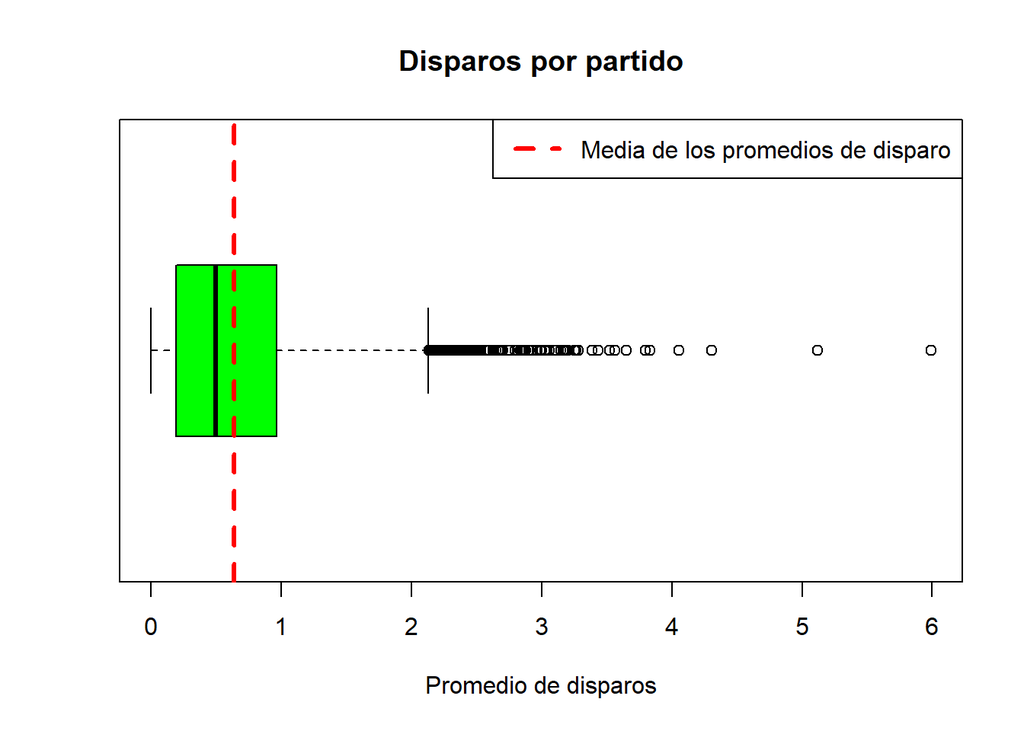

A partir del boxplot de los promedios de disparo por partido de cada jugador se puede evidenciar la existencia de muchos datos atípicos , en donde resaltan dos con valores cercanos al 5 y al 6, mientras que la media de los promedios de disparo se encuentra en 0.64. Podríamos deducir que el resultado gráfico que tenemos está influenciado por promedios de disparo correspondientes a jugadores de posiciones distintas a las de delantero que de modo circunstancial han podido disparar al arco pero que no suelen hacerlo, mienras que la gran cantidad de datos por fuera del RIQ corresponde a delanteros con alto promedio de disparo por partido.

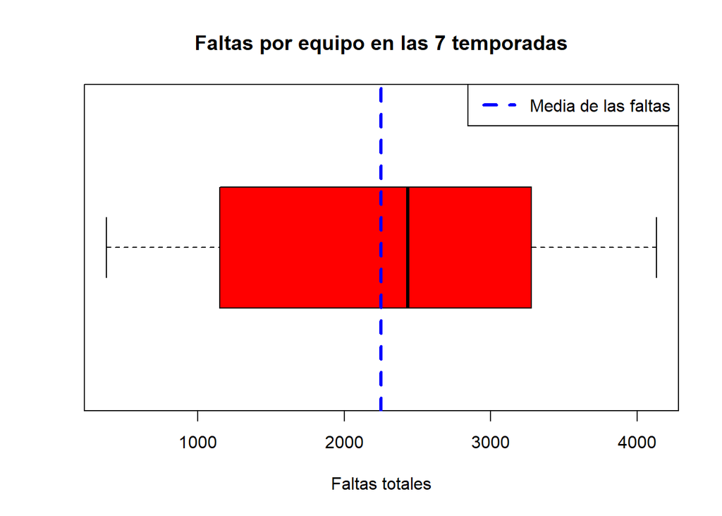

Según el gráfico boxplot del total de faltas por equipo a lo largo de las 7 temporadas, ningún equipo presenta valores atípicos. La mediana de faltas por equipo adquiere un valor ligeramente inferior a las 2500 faltas. Además, la media de las faltas es 2250 (un número cercano a la mediana), por lo que la consideramos como un valor representativo.

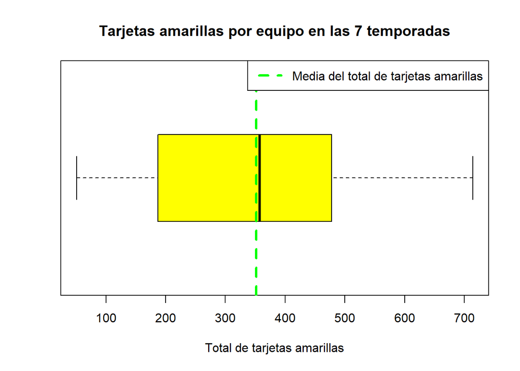

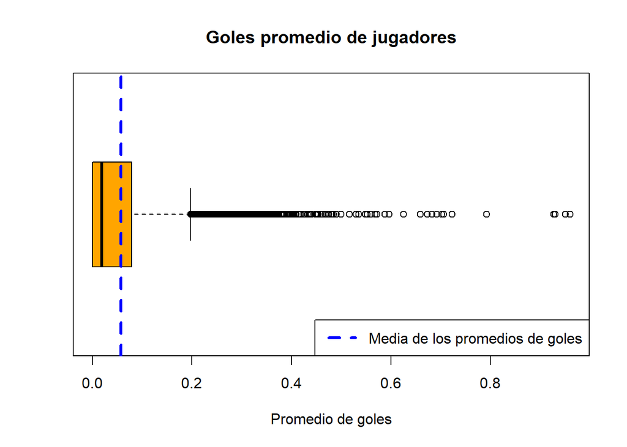

La mayoria de jugadores en un partido anotan 1 o ni un gol, mientras que hay casos muy particulares en la que pocos jugadores tienen un promedio cercano a un gol por partido, cuyos promedios correspsonden a los jugadores mas reconocidos del mundo como lo son Messi o Cristiano Ronaldo. Los puntos que representan datos atípicos, son en su mayoria delanteros, jugadores que estan en constante interacción con el arco del equipo contrario.

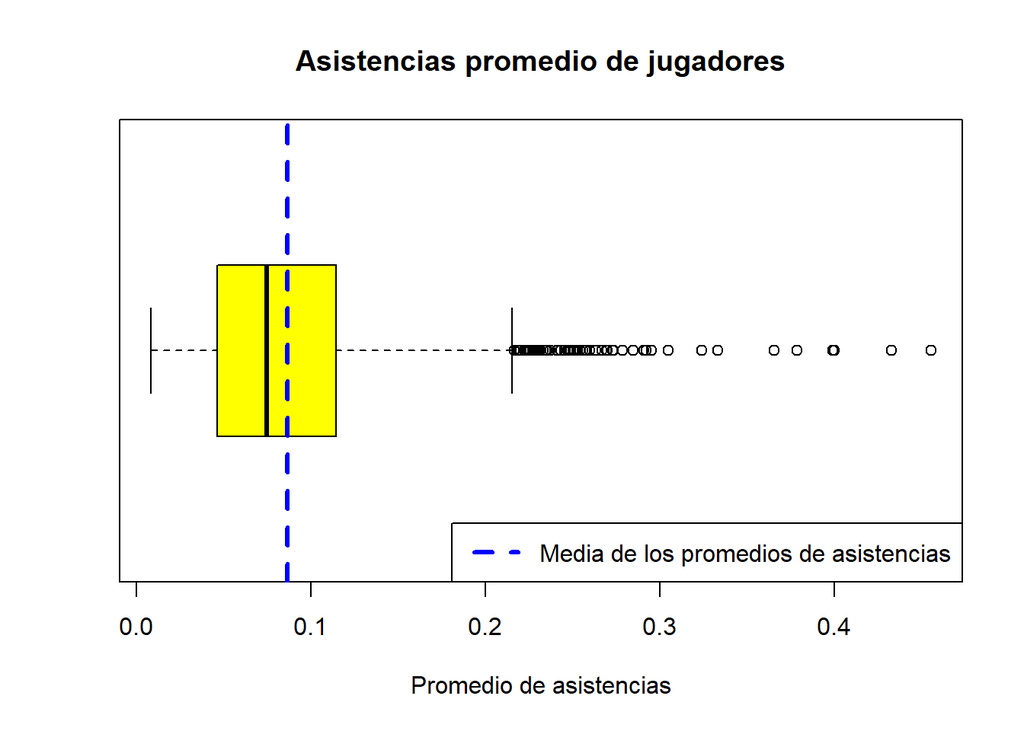

De manera similar a los goles , las asistencias promedio de los jugadores por partido tienen una media alrededor de 0.1, la cual es baja debido a la influencia de jugadores relacionados a roles defensivos que de manera circunstancial pueden dar una asistencia pero que después no lo hacen de nuevo. Asimismo, existe una gran cantidad de datos atípicos correspondientes a promedios altos de jugadores más ofensivos como Messi o De Bruyne.

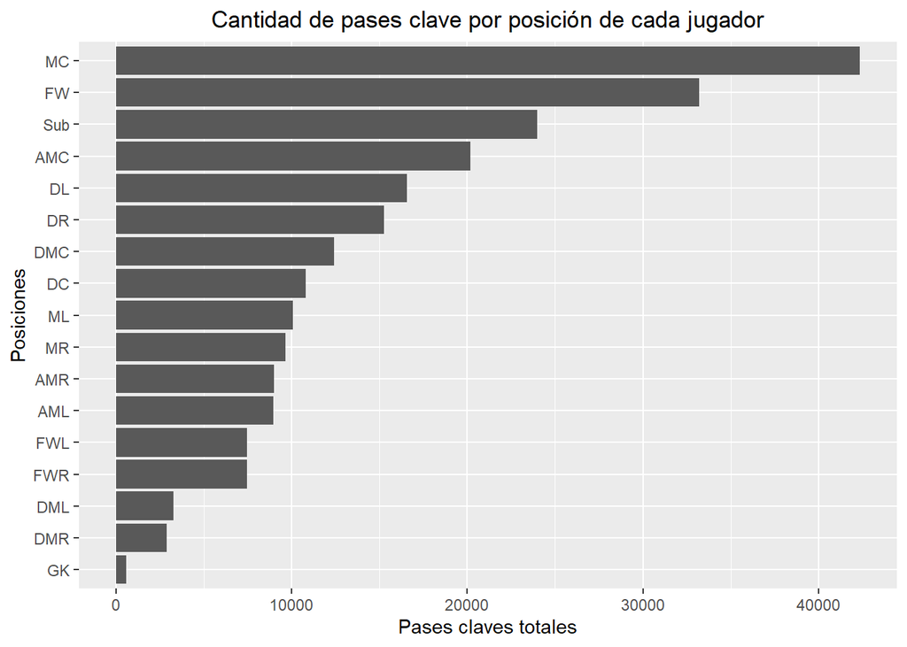

La relevancia de los pases clave es que ha permitido también revelar que existen mediocampistas, no necesariamente ofensivos, pero que sí tienen una gran contribución en la generación de goles, que termina siendo una de las variables más importantes para ganar un partido. La aparición del pase clave, mas allá de la asistencia, es un buen indicador de la contribución que puede tener un mediocampista para llegar al gol.

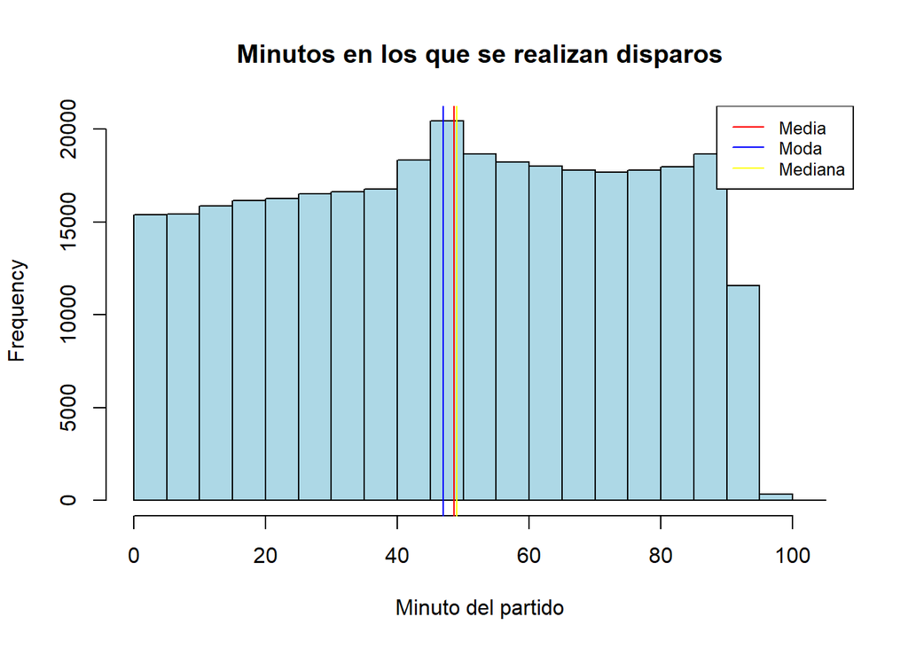

Este histograma de los minutos en los que se realizan disparos nos muestra una distribución simétrica de la variable en cuestión, lo cual se puede apreciar tanto visualmente como a través de la media, la moda y la mediana, las cuales se encuentran en valores aproximados entre sí. La frecuencia de disparos entre el minuto 95 y el 100 es baja pues los partidos no suelen extenderse tantos minutos como para alcanzar los 100.

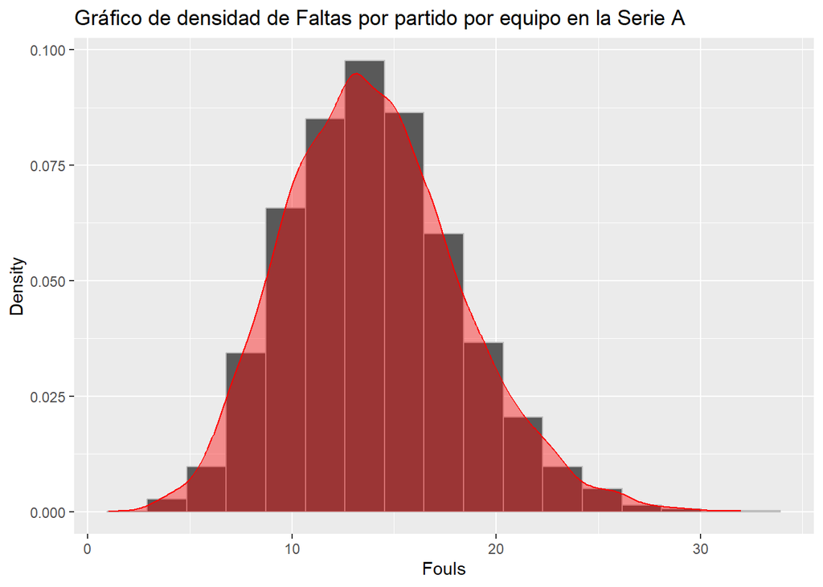

En el gráfico de densidad de las faltas que cometen los equipos de la Serie A (la liga con mayor cantidad de faltas en el periodo 2014-2020) por partido, podemos apreciar una distribución simétrica de esta variable, lo cual nos podría indicar que las faltas se distribuyen de manera normal entre todos los equipos de la primera división italiana. De este modo, al contar con una distribución de este tipo podremos realizar pruebas de hipótesis con esta variable.

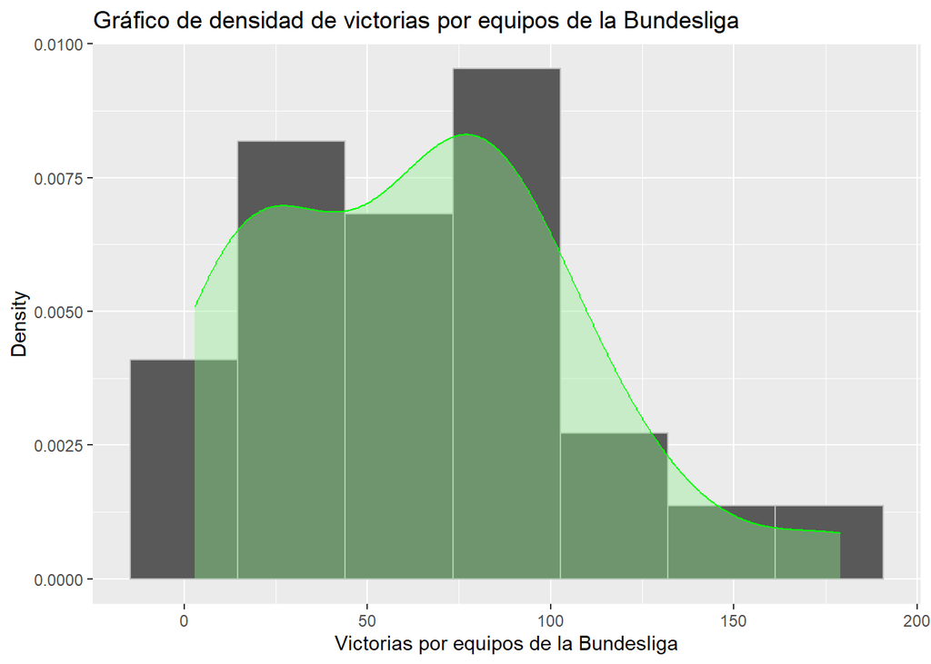